# Analysis of video data from each run

## Introduction

Things which is been analysed throughout the project:

1. Total views
2. Total downloads
3. Participants
4. Key factor derived from the data

## Video Titles

1.1 Welcome to the course video  
1.5 Privacy online and offline video  
1.14 Why would anyone want your data?  
1.17 Preserving privacy in cloud storage: privacy by design video  
1.19 Staying safe online: personal perspectives video  
2.1 Welcome to Week 2: payment security  
2.4 The evolving arms race of payment security  
2.11 Exploring vulnerabilities in online payments  
2.17 The million dollar contactless payment  
3.1 Welcome to Week 3: security in the future home  
3.2 Devices in the future home  
3.14 Exploring security: biometric authentication  
3.15 Exploring security: the Access Control Live Lab

## Run 3

**Total number of views is 732**  
**Total number of downloads 756**

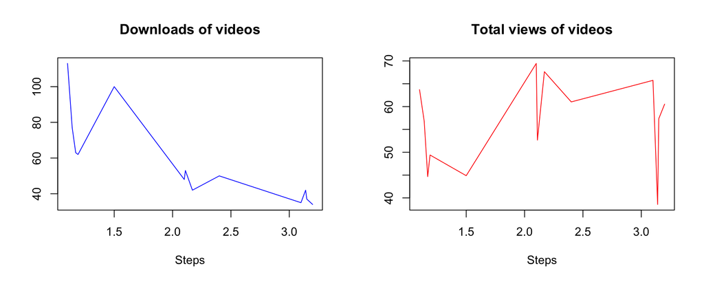

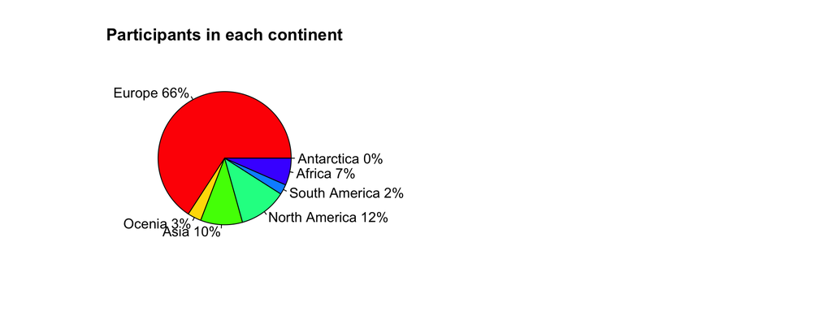

## Run 4

**Total number of views is 720**  
**Total number of downloads 1054**

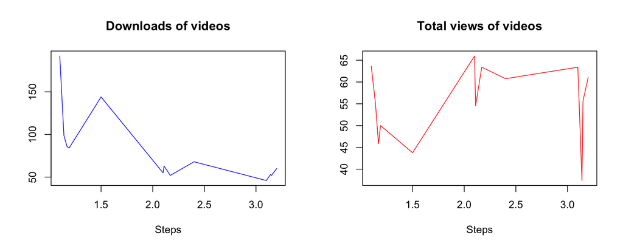

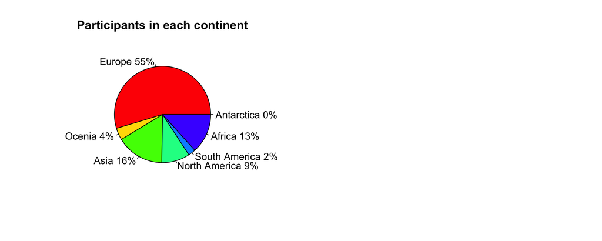

## Run 5

**Total number of views is 787**  
**Total number of downloads 848**

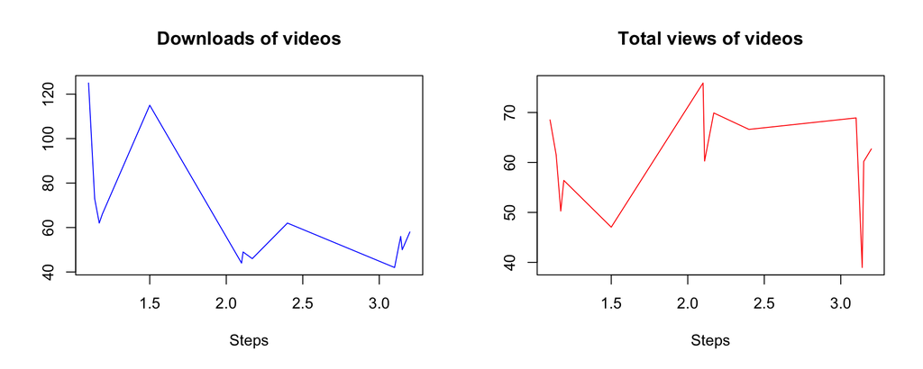

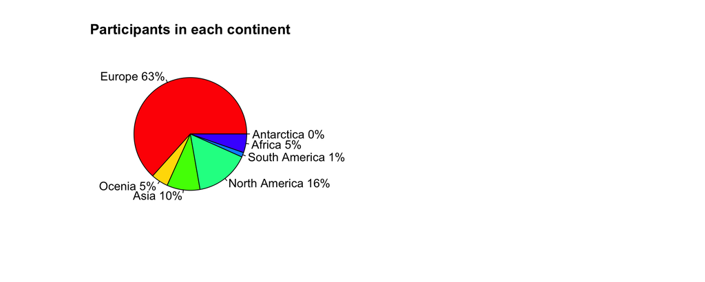

## Run 6

**Total number of views is 753**  
**Total number of downloads 508**

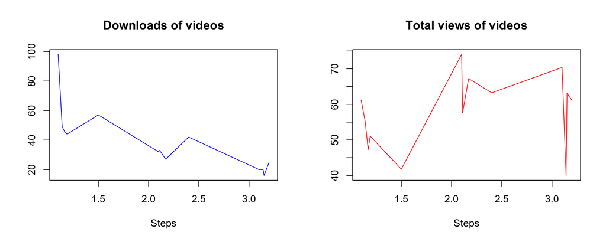

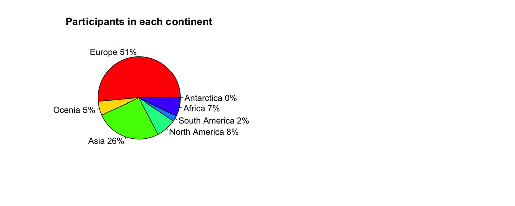

## Run 7

**Total number of views is 723**  
**Total number of downloads 243**

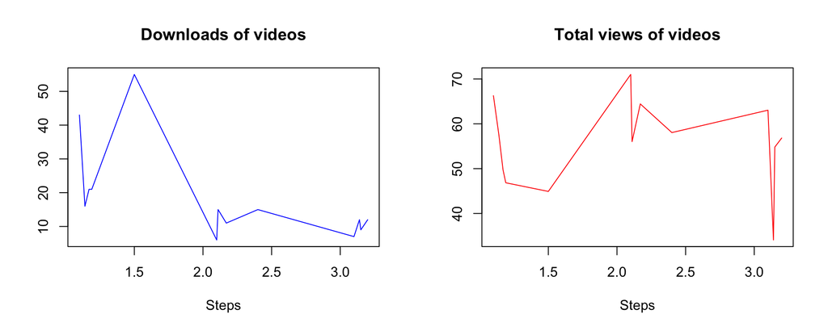

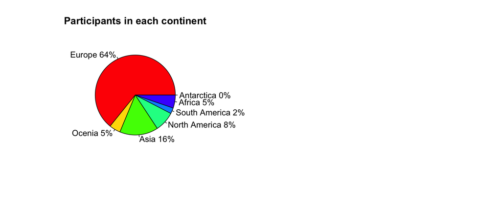

## Key Points

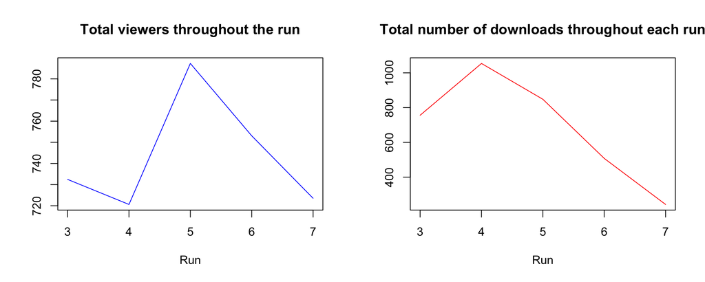

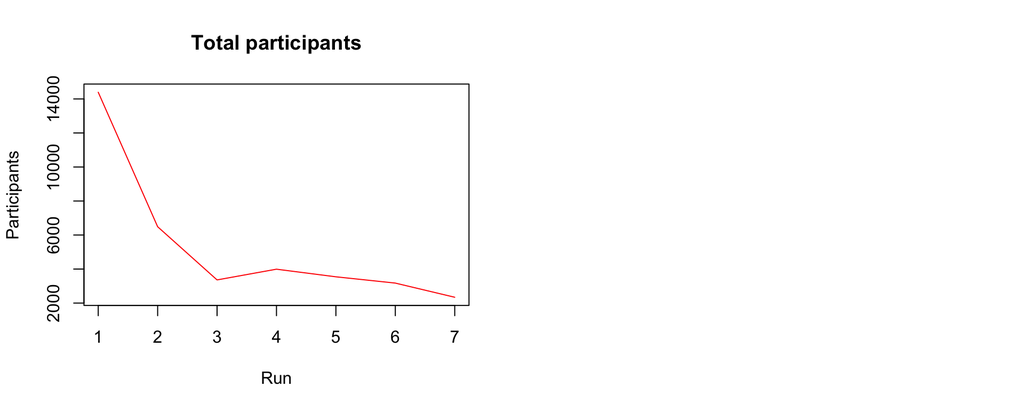